# Targeting a Housing Subsidy

Michael Clifford

November 2, 2023

```r
options(scipen=10000000)

library(tidyverse)
library(kableExtra)
library(caret)
library(knitr)
library(pscl)
library(plotROC)
library(pROC)
library(lubridate)
library(stargazer)
library(gridExtra)
```

```r
palette5 <- c("#981FAC","#CB0F8B","#FF006A","#FE4C35","#FE9900")
palette4 <- c("#981FAC","#FF006A","#FE4C35","#FE9900")
palette2 <- c("#981FAC","#FF006A")

housing <- read.csv("housingSubsidy.csv")
```

## 1. Introduction

The motivation for this analysis is to help the Emil City Department of Housing and Community Development (HCD) better target possible recipients of home repair tax credits. Until now HCD has been reaching out to homeowners at random to promote the credit program without any consideration for the characteristics of the homeowner, resulting in low program participation. To improve the success rate, I will use homeowner data from previous campaigns to account for the attributes that make homeowners more likely to join the program, and to create a predictive model that will allow HCD to use it’s limited resources to more effectively target possible program enrollees and maximize the economic benefits to the community.

## 2. Exploratory Analysis and Engineering New Features

I also re-engineered some categorical variables to make them simpler and more intuitive. First, I reclassified the education variable (now called “edu”) down to 3 categories: Above high school, high school and below, and unknown. I also condensed the months into 4 seasons, as differences between seasons are more stark than between two consecutive months. Finally, I converted the “job” variable, which had several possible values, into a program-entrance average by job (a continuous value) called “job.y.share”, which conveys more information than a simple job descriptor.

```r
housing <- housing %>%
  mutate(edu = ifelse((education =="university.degree" | education =="professional.course"), "aboveHS", ifelse(education == "unknown" | is.na(education), "unknown", "belowHS")))

housing <- housing %>%
  mutate(season = case_when(
    month == "dec" | month == "jan" | month == "feb" ~ "Winter",
    month == "mar" | month == "apr" | month == "may" ~ "Spring",
    month == "jun" | month == "jul" | month == "aug" ~ "Summer",
    month == "sep" | month == "oct" | month == "nov" ~ "Fall"))

housing <- housing %>%
  group_by(job) %>%
  summarize(tot.y = sum(y_numeric),
            n = n(),
            job.y.share = 100*(tot.y/n)) %>%
  dplyr::select(-n, -tot.y) %>%
  right_join(housing, .)

housing <- housing %>%
  mutate(pdays_cat = ifelse(pdays == 999, "no", "yes"))

housing <- housing %>%
  mutate(repair_cat = ifelse(spent_on_repairs <= 5175, ">= 5175", "< 5175"))
```

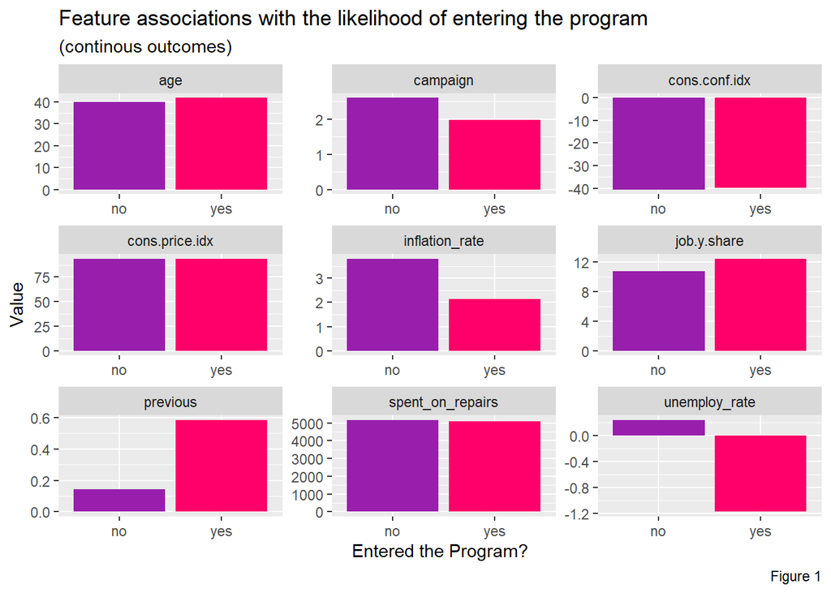

```r
housing %>%
  dplyr::select(y, age, campaign, previous, unemploy_rate, cons.price.idx,
                cons.conf.idx, inflation_rate, spent_on_repairs, job.y.share) %>%
  gather(Variable, value, -y) %>%
    ggplot(aes(y, value, fill=y)) +
      geom_bar(position = "dodge", stat = "summary", fun = "mean") +
      facet_wrap(~Variable, scales = "free") +
      scale_fill_manual(values = palette2) +
      labs(x="Entered the Program?", y="Value",
           title = "Feature associations with the likelihood of entering the program",
           subtitle = "(continous outcomes)",
           caption = "Figure 1") +
      theme(legend.position = "none")
```

Figure 1 shows the mean value of different continuous variables for those that entered the program (“yes”) and those that didn’t (“no”). This suggests a strong correlation between inflation_rate, previous, and unemploy_rate with the possibility that someone chooses to enter the program or not.

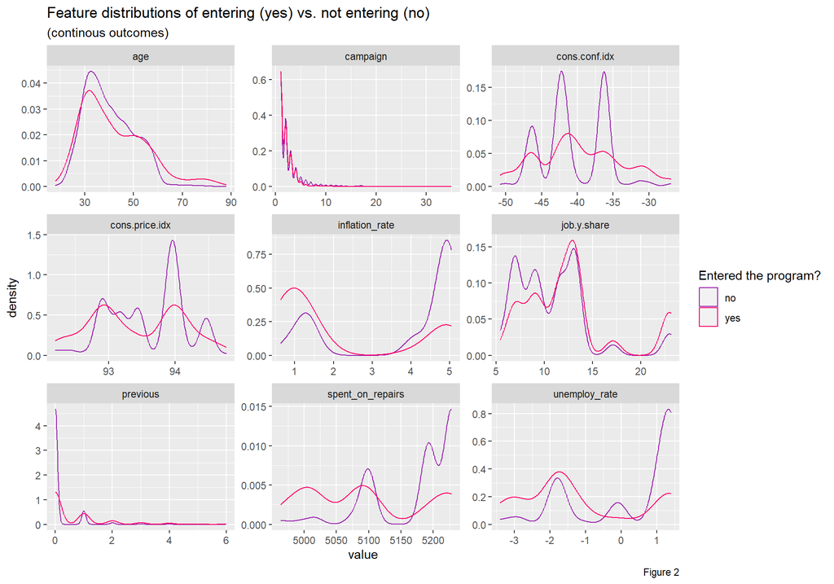

```r
housing %>%
    dplyr::select(y, age, campaign, previous, unemploy_rate, cons.price.idx,
                cons.conf.idx, spent_on_repairs, job.y.share, inflation_rate) %>%
    gather(Variable, value, -y) %>%
    ggplot() +
    geom_density(aes(value, color=y), fill = "transparent") +
    facet_wrap(~Variable, scales = "free") +
    scale_color_manual(values = palette2, name = "Entered the program?") +
    labs(title = "Feature distributions of entering (yes) vs. not entering (no)",
         subtitle = "(continous outcomes)",
         caption = "Figure 2")
```

Figure 2 re-visualizes the continuous variables and more clearly shows the distribution of variables based on program enrollment. The plot for conc.conf.idx, for example, shows that program enrollment is more responsive to the change in value more than the value itself, while program enrollment varies most around the extreme values of inflation_rate and spent_on_repairs (which I reclassified as explained above).

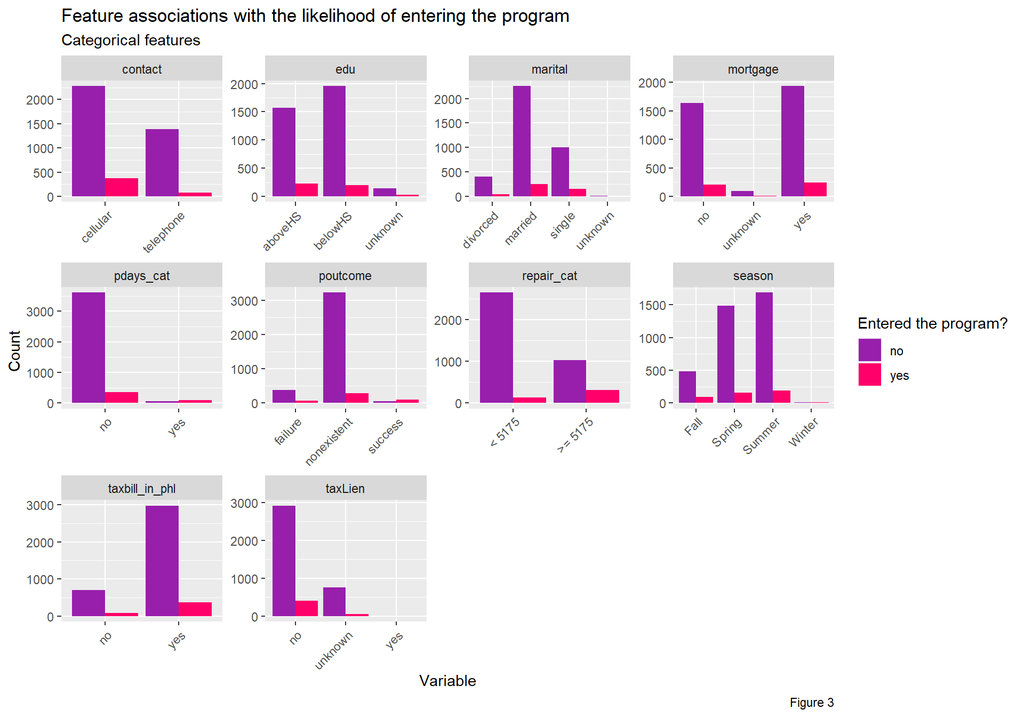

```r
housing %>%
    dplyr::select(y, marital, edu, mortgage, contact, poutcome, taxLien, taxbill_in_phl, season,
                  pdays_cat, repair_cat) %>%
    gather(Variable, value, -y) %>%
    count(Variable, value, y) %>%
      ggplot(., aes(value, n, fill = y)) +
        geom_bar(position = "dodge", stat="identity") +
        facet_wrap(~Variable, scales="free") +
        scale_fill_manual(values = palette2, name = "Entered the program?") +
        labs(x="Variable", y="Count",
             title = "Feature associations with the likelihood of entering the program",
             subtitle = "Categorical features",
             caption = "Figure 3") +
        theme(axis.text.x = element_text(angle = 45, hjust = 1))
```

Figure 3 shows the count of those who did and did not enter the program based on different categorical variables. It is harder to find correlation in this plot as it uses counts, and overall a lot more people declined the program than entered it.

## 3. Running Logistic Regressions

The next step is to run logistic regressions to predict the probability that a homeowner will enroll in the program, based on a combination of the variables discussed above. The data is split 65/35 into a training and test set.

```r
set.seed(3456)
trainIndex <- createDataPartition(housing$y, p = .65,
                                  list = FALSE,
                                  times = 1)
housingTrain <- housing[ trainIndex,]
housingTest  <- housing[-trainIndex,]
```

First, I run a “Kitchen Sink” regression, utilizing all the original variables in the data set.

```r
kitchenModel <- glm(y_numeric ~ .,
                  data=housingTrain %>%
                    dplyr::select(-edu, -job.y.share, -season, -taxLien, -pdays_cat, -repair_cat,
                                  -y),
                  family="binomial" (link="logit"))

summary(kitchenModel)
```

```
##
## Call:
## glm(formula = y_numeric ~ ., family = binomial(link = "logit"),
##     data = housingTrain %>% dplyr::select(-edu, -job.y.share,
##         -season, -taxLien, -pdays_cat, -repair_cat, -y))
##
## Coefficients:
##                                  Estimate   Std. Error z value Pr(>|z|)
## (Intercept)                  -62.19586855 131.70394125  -0.472   0.6368
## X                              0.00005255   0.00006002   0.875   0.3813
## age                            0.00383747   0.00851456   0.451   0.6522
## jobblue-collar                -0.19395586   0.26978580  -0.719   0.4722
## jobentrepreneur               -0.42432097   0.45743139  -0.928   0.3536
## jobhousemaid                  -0.60256812   0.55248641  -1.091   0.2754
## jobmanagement                 -0.29769569   0.30609923  -0.973   0.3308
## jobretired                    -0.06939378   0.37067663  -0.187   0.8515
## jobself-employed              -0.72267757   0.45910449  -1.574   0.1155
## jobservices                   -0.38063019   0.29988752  -1.269   0.2044
## jobstudent                    -0.58636850   0.47512363  -1.234   0.2172
## jobtechnician                 -0.07096711   0.23348744  -0.304   0.7612
## jobunemployed                  0.01409981   0.42873890   0.033   0.9738
## jobunknown                    -0.31265365   0.70013747  -0.447   0.6552
## maritalmarried                -0.00337158   0.23887853  -0.014   0.9887
## maritalsingle                 -0.03590931   0.27433401  -0.131   0.8959
## maritalunknown               -11.78756359 329.19219037  -0.036   0.9714
## educationbasic.6y              0.37735844   0.40058469   0.942   0.3462
## educationbasic.9y             -0.06335464   0.33936436  -0.187   0.8519
## educationhigh.school           0.14771239   0.32365191   0.456   0.6481
## educationilliterate          -13.27033316 882.74356255  -0.015   0.9880
## educationprofessional.course   0.17986922   0.35080890   0.513   0.6081
## educationuniversity.degree     0.30199002   0.32392782   0.932   0.3512
## educationunknown               0.34675034   0.41419957   0.837   0.4025
## mortgageunknown               -0.12385996   0.56929048  -0.218   0.8278
## mortgageyes                   -0.20775344   0.14287048  -1.454   0.1459
## taxbill_in_phlyes              0.18175191   0.20074694   0.905   0.3653
## contacttelephone              -0.63330786   0.28513527  -2.221   0.0263 *
## monthaug                       0.02148474   0.44373694   0.048   0.9614
## monthdec                       1.82243473   0.78002383   2.336   0.0195 *
## monthjul                       0.10188428   0.37384444   0.273   0.7852
## monthjun                       0.06395839   0.47202270   0.135   0.8922
```

[output cut: 14 more lines]

```
## unemploy_rate                 -0.93563334   0.48646189  -1.923   0.0544 .
## cons.price.idx                 0.89783251   0.86200128   1.042   0.2976
## cons.conf.idx                  0.02113176   0.02936107   0.720   0.4717
## inflation_rate                 0.51062205   0.44835667   1.139   0.2548
## spent_on_repairs              -0.00477565   0.01074639  -0.444   0.6568
## ---
## Signif. codes:  0 '***' 0.001 '**' 0.01 '*' 0.05 '.' 0.1 ' ' 1
##
## (Dispersion parameter for binomial family taken to be 1)
##
##     Null deviance: 1853.7  on 2678  degrees of freedom
## Residual deviance: 1488.2  on 2628  degrees of freedom
## AIC: 1590.2
##
## Number of Fisher Scoring iterations: 13
```

Figure 4: Logistic Regression Results for “Kitchen Sink” Model

Next, I run an “Engineered” regression utilizing the new engineered features (removing the featurs they are based on) and removing other variables that either had low significance or colinearity with other variables (for instance, cons.price.idx, cons.conf.idx, and inflation_rate appear to be highly correlated with one another, so I only kept cons.conf.idx)

```r
housingModel  <- glm(y_numeric ~ .,
                  data=housingTrain %>%
                    dplyr::select(-age, -month, -education, -previous,
                                  -pdays, -job, -taxLien, -spent_on_repairs, -cons.price.idx,
                                  -inflation_rate,
                                   -X, -y),
                  family="binomial" (link="logit"))

summary(housingModel)
```

```
##
## Call:
## glm(formula = y_numeric ~ ., family = binomial(link = "logit"),
##     data = housingTrain %>% dplyr::select(-age, -month, -education,
##         -previous, -pdays, -job, -taxLien, -spent_on_repairs,
##         -cons.price.idx, -inflation_rate, -X, -y))
##
## Coefficients:
##                      Estimate Std. Error z value Pr(>|z|)
## (Intercept)          -1.71077    0.77025  -2.221  0.02635 *
## maritalmarried       -0.07136    0.22898  -0.312  0.75532
## maritalsingle        -0.11270    0.24346  -0.463  0.64343
## maritalunknown      -11.94280  329.17589  -0.036  0.97106
## mortgageunknown      -0.03075    0.52010  -0.059  0.95286
## mortgageyes          -0.20384    0.13864  -1.470  0.14147
## taxbill_in_phlyes     0.18347    0.19521   0.940  0.34729
## contacttelephone     -0.11557    0.18718  -0.617  0.53695
## day_of_weekmon       -0.27346    0.21349  -1.281  0.20023
## day_of_weekthu       -0.15985    0.20947  -0.763  0.44539
## day_of_weektue       -0.18710    0.21007  -0.891  0.37313
## day_of_weekwed       -0.28760    0.22447  -1.281  0.20011
## campaign             -0.11689    0.04314  -2.709  0.00674 **
## poutcomenonexistent   0.32878    0.21759   1.511  0.13079
## poutcomesuccess       0.97668    0.64072   1.524  0.12742
## unemploy_rate        -0.01204    0.15029  -0.080  0.93613
## cons.conf.idx         0.02433    0.01631   1.492  0.13577
## edubelowHS           -0.26040    0.14349  -1.815  0.06955 .
## eduunknown           -0.01677    0.31751  -0.053  0.95788
## seasonSpring         -0.51882    0.24203  -2.144  0.03207 *
## seasonSummer          0.13350    0.22230   0.601  0.54813
## seasonWinter          2.02543    0.67530   2.999  0.00271 **
## job.y.share           0.02324    0.01601   1.451  0.14675
## pdays_catyes          1.09585    0.63416   1.728  0.08398 .
## repair_cat>= 5175     1.47333    0.52369   2.813  0.00490 **
## ---
## Signif. codes:  0 '***' 0.001 '**' 0.01 '*' 0.05 '.' 0.1 ' ' 1
##
## (Dispersion parameter for binomial family taken to be 1)
##
##     Null deviance: 1853.7  on 2678  degrees of freedom
## Residual deviance: 1546.0  on 2654  degrees of freedom
## AIC: 1596
##
## Number of Fisher Scoring iterations: 13
```

Figure 5: Logistic Regression Results for Engineered Model (“housingModel”)

```r
stargazer(pR2(kitchenModel), type = "text", title = "Kitchen Sink Model pseudo-R2 measures")
```

```
## fitting null model for pseudo-r2
##
## Kitchen Sink Model pseudo-R2 measures
## ==============================================
## llh      llhNull    G2    McFadden r2ML  r2CU
## ----------------------------------------------
## -744.098 -926.871 365.547  0.197   0.128 0.255
## ----------------------------------------------
```

```r
stargazer(pR2(housingModel), type = "text", title = "Engineered Model pseudo-R2 measures")
```

```
## fitting null model for pseudo-r2
##
## Engineered Model pseudo-R2 measures
## ==============================================
## llh      llhNull    G2    McFadden r2ML  r2CU
## ----------------------------------------------
## -772.989 -926.871 307.764  0.166   0.109 0.217
## ----------------------------------------------
```

Figure 6: pseudo-r2 results for Kitchen Sink and Enginered Logistic Regression Models

As seen in Figure 6, after much tinkering with the model and engineering features, I was unable to create a model with a better fit (in fact, the McFadden score decreased by about .03 from the Kitchen Sink to the Engineered model). This does not account for the confusion matrix/metrics and ROC curve though, which are also important for evaluating a logistic regression model such as this one.

```r
testProbs.kit <- data.frame(Outcome = as.factor(housingTest$y_numeric),
                        Probs = predict(kitchenModel, housingTest, type= "response"))

testProbs <- data.frame(Outcome = as.factor(housingTest$y_numeric),
                        Probs = predict(housingModel, housingTest, type= "response"))
```

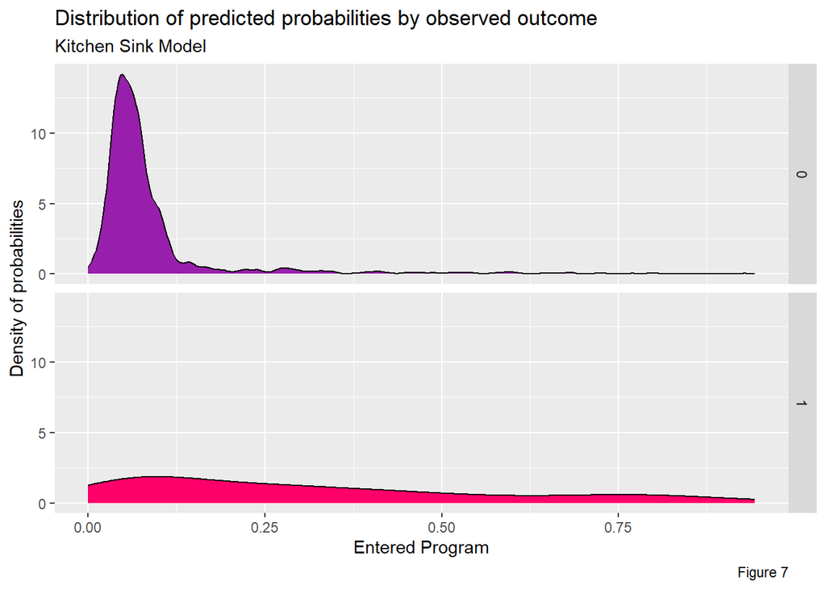

```r
ggplot(testProbs.kit, aes(x = Probs, fill = as.factor(Outcome))) +
  geom_density() +
  facet_grid(Outcome ~ .) +
  scale_fill_manual(values = palette2) +
  labs(x = "Entered Program", y = "Density of probabilities",
       title = "Distribution of predicted probabilities by observed outcome",
       subtitle = "Kitchen Sink Model",
       caption = "Figure 7") +
  theme(strip.text.x = element_text(size = 18),
        legend.position = "none")
```

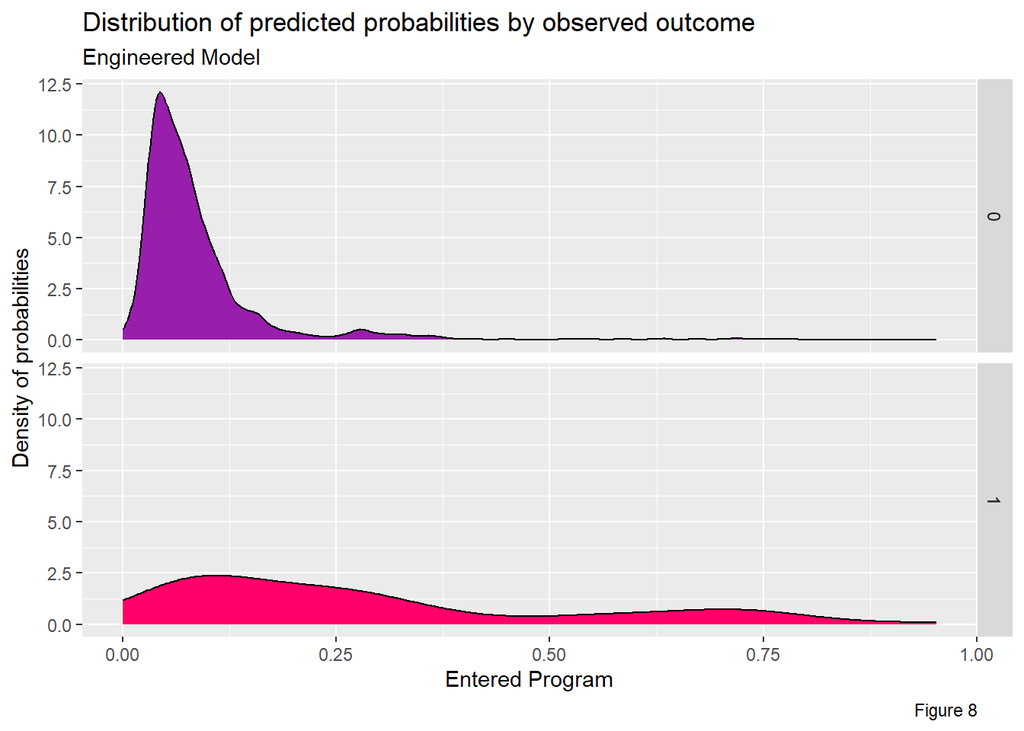

```r
ggplot(testProbs, aes(x = Probs, fill = as.factor(Outcome))) +
  geom_density() +
  facet_grid(Outcome ~ .) +
  scale_fill_manual(values = palette2) +
  labs(x = "Entered Program", y = "Density of probabilities",
       title = "Distribution of predicted probabilities by observed outcome",
       subtitle = "Engineered Model",
       caption = "Figure 8") +
  theme(strip.text.x = element_text(size = 18),
        legend.position = "none")
```

Figures 7 and 8 show the distribution of predicted probabilities by the observed outcome, after running both models on the test data. In both cases, a large range of probabilities are assigned to homeowners that enrolled in the program, suggesting there are factors to this decision that are not reflected in the data. On the other hand, both models appear quite good at predicting those who deline the program.

### 3.1 Confusion Matrices

A Confusion matrix is made for each model, setting 0.5 as the threshold for the predicted outcome.

```r
testProbs.kit <-
  testProbs.kit %>%
  mutate(predOutcome  = as.factor(ifelse(testProbs.kit$Probs > 0.5 , 1, 0)))

testProbs <-
  testProbs %>%
  mutate(predOutcome  = as.factor(ifelse(testProbs$Probs > 0.5 , 1, 0)))
```

```r
caret::confusionMatrix(testProbs.kit$predOutcome, testProbs.kit$Outcome,
                       positive = "1")
```

```
## Confusion Matrix and Statistics
##
##           Reference
## Prediction    0    1
##          0 1258  121
##          1   25   36
##
##                Accuracy : 0.8986
##                  95% CI : (0.8819, 0.9137)
##     No Information Rate : 0.891
##     P-Value [Acc > NIR] : 0.1879
##
##                   Kappa : 0.2868
##
##  Mcnemar's Test P-Value : 0.000000000000003773
##
##             Sensitivity : 0.22930
##             Specificity : 0.98051
##          Pos Pred Value : 0.59016
##          Neg Pred Value : 0.91226
##              Prevalence : 0.10903
##          Detection Rate : 0.02500
##    Detection Prevalence : 0.04236
##       Balanced Accuracy : 0.60491
##
##        'Positive' Class : 1
##
```

Figure 9: Confusion Matrix for Kitchen Sink Model

```r
caret::confusionMatrix(testProbs$predOutcome, testProbs$Outcome,
                       positive = "1")
```

```
## Confusion Matrix and Statistics
##
##           Reference
## Prediction    0    1
##          0 1263  122
##          1   20   35
##
##                Accuracy : 0.9014
##                  95% CI : (0.8848, 0.9163)
##     No Information Rate : 0.891
##     P-Value [Acc > NIR] : 0.109
##
##                   Kappa : 0.29
##
##  Mcnemar's Test P-Value : <0.0000000000000002
##
##             Sensitivity : 0.22293
##             Specificity : 0.98441
##          Pos Pred Value : 0.63636
##          Neg Pred Value : 0.91191
##              Prevalence : 0.10903
##          Detection Rate : 0.02431
##    Detection Prevalence : 0.03819
##       Balanced Accuracy : 0.60367
##
##        'Positive' Class : 1
##
```

Figure 10: Confusion Matrix for Engineered Model

Figure 9 and 10 show that, overall, the engineered model is a little more accurate than the engineered one. Both have high specificity (true negative) and low sensitivity (true positive). The sensitivity for the engineered model is slightly lower.

### 3.2 Cross-Validation and ROC Curves

To further test the models I run a 100-fold cross-validation on both.

```r
ctrl <- trainControl(method = "cv", number = 100, classProbs=TRUE, summaryFunction=twoClassSummary)

housing2 <- housing %>%
    mutate(y2 = ifelse(y == "no", "yes", "no"))

cvFit_kitchen <- train(y2 ~ .,
                  data=housing2 %>%
                   na.omit() %>%
                    dplyr::select(-edu, -job.y.share, -season, -taxLien, -pdays_cat, -repair_cat,
                                  -y_numeric, -y),
                method="glm", family="binomial",
                metric="ROC", trControl = ctrl)

#cvFit_kitchen

cvFit_housing <- train(y2 ~ .,
                  data=housing2 %>%
                   na.omit() %>%
                    dplyr::select(-age, -month, -education, -previous,
                                  -pdays, -job, -taxLien, -spent_on_repairs, -cons.price.idx,
                                  -inflation_rate,
                                   -X, -y_numeric, -y),
                method="glm", family="binomial",
                metric="ROC", trControl = ctrl)
```

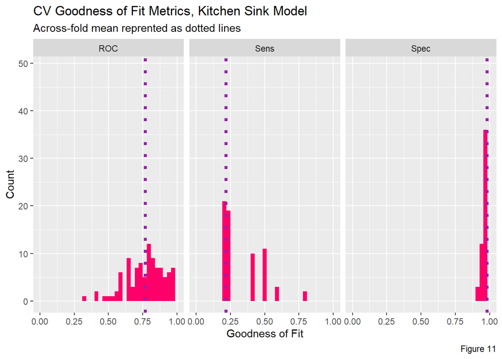

```r
dplyr::select(cvFit_kitchen$resample, -Resample) %>%
  gather(metric, value) %>%
  left_join(gather(cvFit_kitchen$results[2:4], metric, mean)) %>%
  ggplot(aes(value)) +
    geom_histogram(bins=35, fill = "#FF006A") +
    facet_wrap(~metric) +
    geom_vline(aes(xintercept = mean), colour = "#981FAC", linetype = 3, size = 1.5) +
    scale_x_continuous(limits = c(0, 1)) +
    labs(x="Goodness of Fit", y="Count", title="CV Goodness of Fit Metrics, Kitchen Sink Model",
         subtitle = "Across-fold mean reprented as dotted lines",
         caption = "Figure 11")
```

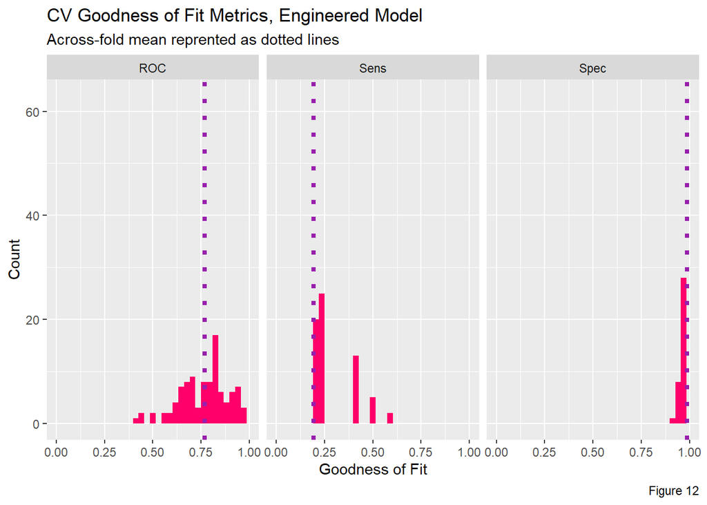

```r
dplyr::select(cvFit_housing$resample, -Resample) %>%
  gather(metric, value) %>%
  left_join(gather(cvFit_housing$results[2:4], metric, mean)) %>%
  ggplot(aes(value)) +
    geom_histogram(bins=35, fill = "#FF006A") +
    facet_wrap(~metric) +
    geom_vline(aes(xintercept = mean), colour = "#981FAC", linetype = 3, size = 1.5) +
    scale_x_continuous(limits = c(0, 1)) +
    labs(x="Goodness of Fit", y="Count", title="CV Goodness of Fit Metrics, Engineered Model",
         subtitle = "Across-fold mean reprented as dotted lines",
         caption = "Figure 12")
```

Figures 11 and 12 show the results of the cross-validation. As seen in previous summaries, the results for both models are quite similar. Both show consistently high specificity and consistently low sensitivity (though there is some variation). The ROC for both models varies more considerably, though is clustered around 0.75, meaning both models are better predictors than a “coin-flip” in almost all folds.

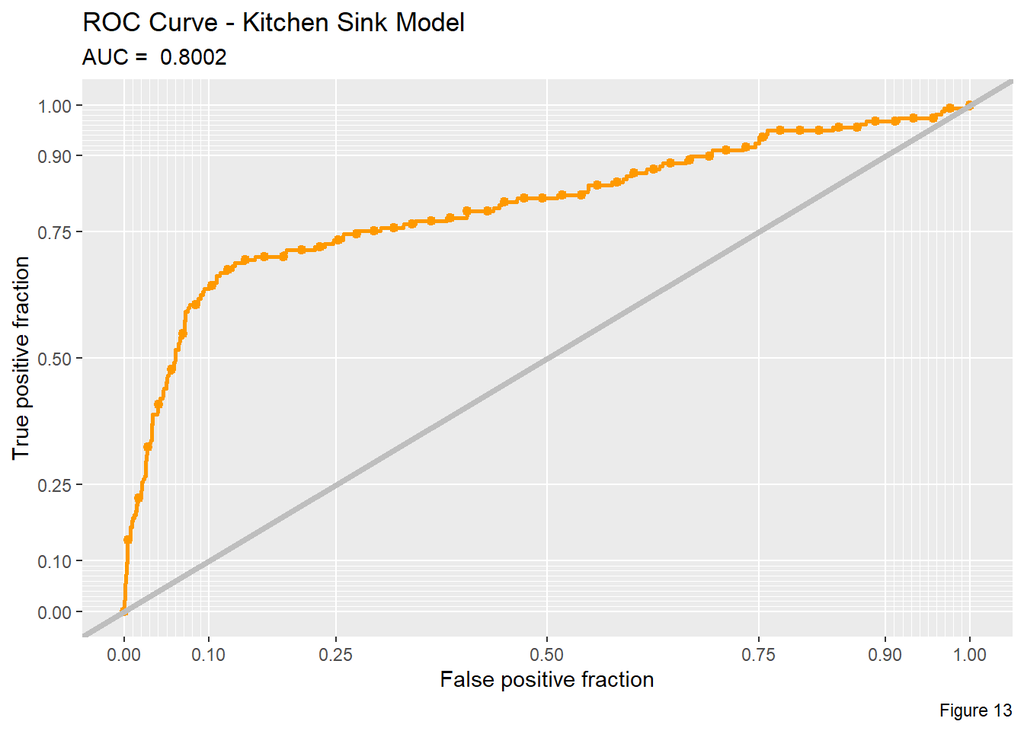

```r
ggplot(testProbs.kit, aes(d = as.numeric(Outcome), m = Probs)) +
  geom_roc(n.cuts = 50, labels = FALSE, colour = "#FE9900") +
  style_roc(theme = theme_grey) +
  geom_abline(slope = 1, intercept = 0, size = 1.5, color = 'grey') +
  labs(title = "ROC Curve - Kitchen Sink Model",
       subtitle = paste("AUC = ", round(auc(testProbs.kit$Outcome, testProbs.kit$Probs), 4)),
       caption = "Figure 13")
```

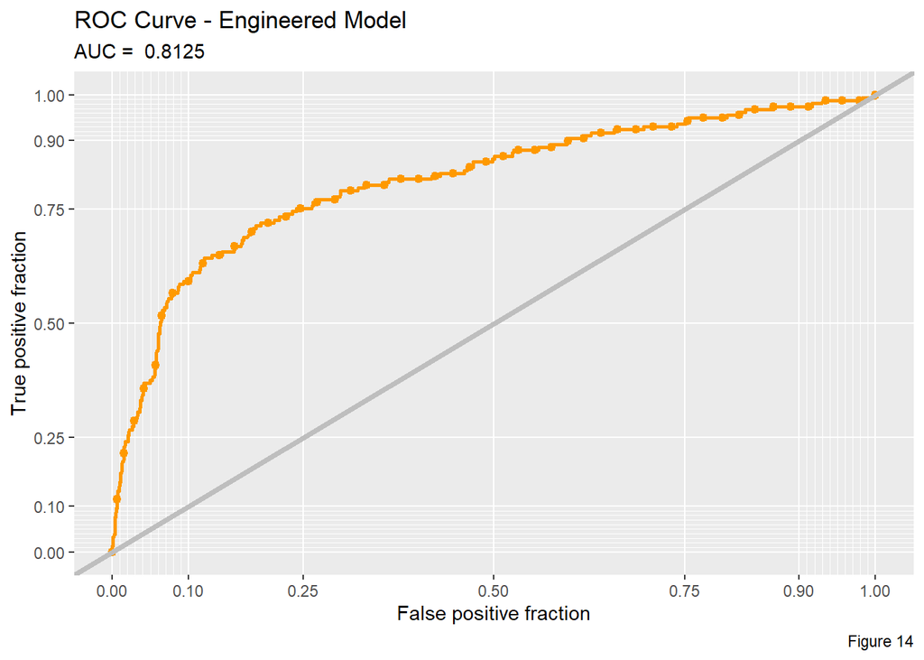

```r
ggplot(testProbs, aes(d = as.numeric(Outcome), m = Probs)) +
  geom_roc(n.cuts = 50, labels = FALSE, colour = "#FE9900") +
  style_roc(theme = theme_grey) +
  geom_abline(slope = 1, intercept = 0, size = 1.5, color = 'grey') +
  labs(title = "ROC Curve - Engineered Model",
       subtitle = paste("AUC = ", round(auc(testProbs$Outcome, testProbs$Probs), 4)),
       caption = "Figure 14")
```

Figures 13 and 14 show the ROC curves for the Kitchen Sink and Engineered models. Both are clearly better better than a “coin-flip” approach. The Engineered model has a larger Area Under the Curve (AUC), suggesting a slightly better fit.

## 4. Cost-Benefit Analysis

To quantify the potential value of my (Engineered) model, I do a cost/benefit analysis for each possible outcome.

If a true negative is predicted, than the cost/benefit is 0, as no marketing resources or credits are allocated to that person.

If a true positive is predicted, the cost is 2850 (for marketing outreach) + 0.25x5000 (the cost of the credit multiplied by 0.25, as it is assumed that only 25% of those that join the program will ultimately receive the $5000 credit). Since I represent a public authority concerned with the welfare of it’s citizens, I consider the expected home value premium to be a benefit of the program, and so for each positive prediction the benefit is (10,000 + 56,000)x.25 - the combined premium of the individual and neighboring home values, multiplied by .25 for the 25% that will ultimately receive the credit.

In the case of a false negative, the cost/benefit is 0, as these homeowners probably signed up or reasons unrelated to this campaign.

Finally, if there is a false positive the cost is just the cost of marketing to that person (2850), with no benefit.

```r
cost_benefit_table <-
   testProbs %>%
      count(predOutcome, Outcome) %>%
      summarize(True_Negative = sum(n[predOutcome==0 & Outcome==0]),
                True_Positive = sum(n[predOutcome==1 & Outcome==1]),
                False_Negative = sum(n[predOutcome==0 & Outcome==1]),
                False_Positive = sum(n[predOutcome==1 & Outcome==0])) %>%
       gather(Variable, Count) %>%
       mutate(Benefit =
               ifelse(Variable == "True_Negative", 0,
               ifelse(Variable == "True_Positive",(((-2850) - (1250)  + 16500)*Count ),
               ifelse(Variable == "False_Negative", 0,
               ifelse(Variable == "False_Positive", (-2850) * Count, 0))))) %>%
    bind_cols(data.frame(Description = c(
              "We correctly predicted not entering the credit program.",
              "We correctly predicted entering the credit program.",
              "We predicted not entering the credit program and customer entered.",
              "We predicted entering the credit program and customer did not.")))

kable(cost_benefit_table,
       caption = "Figure 15: Cost/Benefit Table by Confusion Metric") %>% kable_styling()
```

Figure 15: Cost/Benefit Table by Confusion Metric

| Variable | Count | Benefit | Description |
| --- | --- | --- | --- |
| True_Negative | 1263 | 0 | We correctly predicted not entering the credit program. |
| True_Positive | 35 | 434000 | We correctly predicted entering the credit program. |
| False_Negative | 122 | 0 | We predicted not entering the credit program and customer entered. |
| False_Positive | 20 | -57000 | We predicted entering the credit program and customer did not. |

Figure 15 shows the count of each type of prediction in our data test set, using a 0.5 threshold, and the total cost/benefit associated with each. In this case there is a net benefit.

```r
iterateThresholds <- function(data) {
  x = .01
  all_prediction <- data.frame()
  while (x <= 1) {

  this_prediction <-
      testProbs %>%
      mutate(predOutcome = ifelse(Probs > x, 1, 0)) %>%
      count(predOutcome, Outcome) %>%
      summarize(True_Negative = sum(n[predOutcome==0 & Outcome==0]),
                True_Positive = sum(n[predOutcome==1 & Outcome==1]),
                False_Negative = sum(n[predOutcome==0 & Outcome==1]),
                False_Positive = sum(n[predOutcome==1 & Outcome==0])) %>%
     gather(Variable, Count) %>%
     mutate(Benefit =
               ifelse(Variable == "True_Negative", Count * 0,
               ifelse(Variable == "True_Positive",((-2850) * Count - (1250) * Count + 16500 * Count),
               ifelse(Variable == "False_Negative", Count * 0,
               ifelse(Variable == "False_Positive", (-2850) * Count, 0)))),
            Threshold = x)

  all_prediction <- rbind(all_prediction, this_prediction)
  x <- x + .01
  }
return(all_prediction)
}
```

```r
whichThreshold <- iterateThresholds(testProbs)

whichThreshold_benefit <-
  whichThreshold %>%
    group_by(Threshold) %>%
    summarize(Benefit = sum(Benefit))

#   ggplot(whichThreshold_benefit)+
#   geom_line(aes(x = Threshold, y = Benefit))+
#   geom_vline(xintercept =  pull(arrange(whichThreshold_benefit, -Benefit)[1,1]))+
#     labs(title = "Model Benefits By Threshold For Test Sample",
#          subtitle = "Vertical Line Denotes Optimal Threshold",
#          caption = "Figure 16")
```

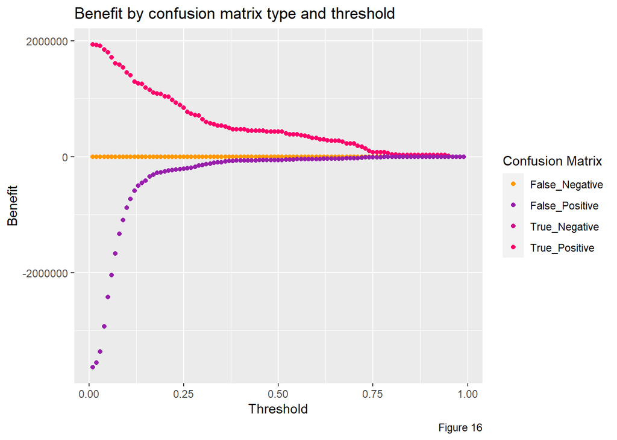

```r
whichThreshold %>%
  ggplot(.,aes(Threshold, Benefit, colour = Variable)) +
  geom_point() +
  scale_colour_manual(values = palette5[c(5, 1:3)]) +
  labs(title = "Benefit by confusion matrix type and threshold",
       y = "Benefit",
       caption = "Figure 16") +
  guides(colour=guide_legend(title = "Confusion Matrix"))
```

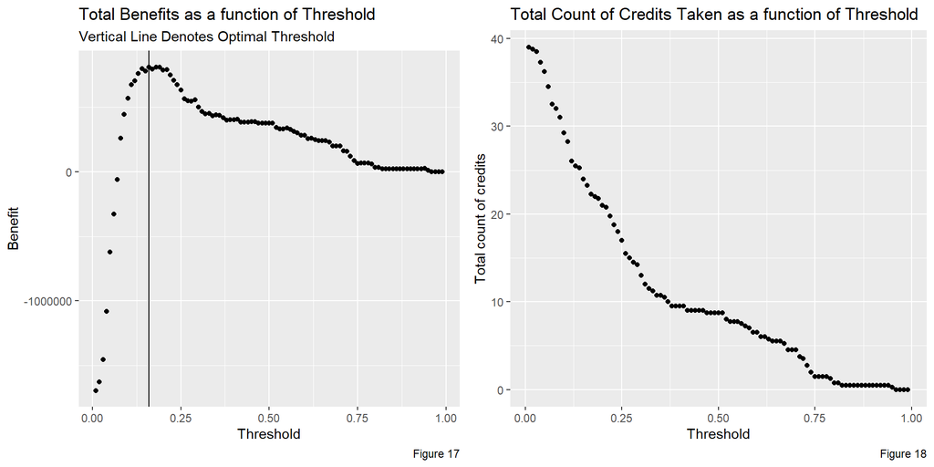

```r
grid.arrange(ncol=2,
whichThreshold_benefit %>%
  ggplot(aes(Threshold, Benefit)) +
    geom_point() +
    geom_vline(xintercept = pull(arrange(whichThreshold_benefit, -Benefit)[1,1])) +
    scale_colour_manual(values = palette2) +
    labs(title = "Total Benefits as a function of Threshold",
         subtitle = "Vertical Line Denotes Optimal Threshold",
         caption = "Figure 17"),

whichThreshold %>%
  dplyr::filter(Variable == "True_Positive") %>%
  ggplot(aes(Threshold, Count * .25)) +
  geom_point() +
    scale_colour_manual(values = palette2) +
    labs(title = "Total Count of Credits Taken as a function of Threshold",
         y = "Total count of credits",
         caption = "Figure 18"))
```

Figures 17 and 18 show how the net benefit and credits distributed change at varying thresholds. The highest (optimal) benefit is at threshold 0.16, and the benefit slowly declines as the threshold is increased from there. This reflects the wide range of predicted probabilities for program enrollees as seen in figures 7 and 8. Unsurprisingly, as the threshold for a “yes” prediction is raised, less credits are allocated, as less people are predicted to enroll in the program.

```r
optimal <- pull(arrange(whichThreshold_benefit, -Benefit)[1,1])

whichThreshold_summary <-
  whichThreshold %>%
  dplyr::filter(Threshold == "0.5" | Threshold == optimal) %>%
  mutate(Count_credit = ifelse(Variable == "True_Positive", Count * .25, 0)) %>%
  group_by(Threshold) %>%
  summarize(Total_Benefit = sum(Benefit),
            Total_Count_of_Credits = round(sum(Count_credit)))


kable(whichThreshold_summary, caption = "Figure 19: Total Benefits and Credits Taken by Threshold
      (0.16 = Optimal)") %>%
  kable_styling()
```

Figure 19: Total Benefits and Credits Taken by Threshold (0.16 = Optimal)

| Threshold | Total_Benefit | Total_Count_of_Credits |
| --- | --- | --- |
| 0.16 | 811200 | 23 |
| 0.50 | 377000 | 9 |

Figure 19 shows the total net benefit and number of credits allocated for the optimal (0.16) threshold and the 0.50 threshold.

## 5. Conclusion

Given that the Emil City HCD is currently just reaching out to homeowners at random, I recommend using my model over the status quo. While it is not perfect, it at least takes into account different attributes of the city’s homeowners, and thus will probably pick out more interested homeowners than random selection. Furthermore the cost-benefit analysis shows it can create a net benefit to the city. In the future I would also do interviews with people that enroll in the program to get a sense of why they chose to do so, and use that information to better target new homeowners.

The model could be improved with a higher sensitivity. Right now my engineered model is not better than the “Kitchen Sink” regression in this regard. As seen in Figures 7 and 8, both models predict a large range of probabilities for homeowners who actually entered the program, with a skew below 0.5. Thus both models are going to struggle to accurately predict positive outcomes, especially with higher thresholds. On the other hand, the data appears to be quite good at predicting people who choose not to enroll. There may be factors that influence people’s decisions that aren’t reflected in the available data. There are also many more people that have declined the program in the past than those that have enrolled, possibly creating a bias in the data against those that enroll in the program. By abandoning the random selection and adopting my own model, the HCD may be able to at least reduce this imbalance, and in the future be able to create an even better model using less biased data.